# Flight_Capstone

Nitin Yadav

29/02/2020

# Problem Statement

Airline industries are in continuous tussle to get more and more customers and in turn are working on very thin margins. The price of flight tickets are very unpredictable considering the dynamic nature of business and governing the law of demand and supply. At times we have noted that for a particular city or destination when we search for flight price , the price keeps getting dynamically updated depending on the search criteria, seat availability, date and time of travel etc. Hence it becomes very important for the Airline industry to have a right price prediction mechanism which is backed up by data and helps the industry to take a data driven decision.

# Need of Study Project

This is a problem of machine learning where we have been given 2 data sets i.e Train and Test set. Train data consist of 10683 records Test data consist of 2671 records

# Understanding business/social opportunity

This is a MAchine learning problem based on supervised learning. Here we train the algorithm using the Train dataset. In supervised machine learnng we know the Target variable and we try to identify the kep predictors on which the response variable (Y) is dependent. Based on the trained machine model, we then try to predict the target using a Test set. This is very crucial in Airline industry as price of a flight is very important parameter for a customer to take the travel decision and a right price point will be beneficial for both customer and the Airline company. Hence the better the MAchine learning model, better would be the accuracy and hence minimum error.

```r
# Loading  required libraries

library(readxl)
library(readr)
library(dplyr)
```

```r
library(corrplot)
library(mice)
library(DMwR)
library(car)
library(caret)
library(SDMTools)
library(lattice)
library(tidyr)
library(data.table)
library(chron)
library(scales)
library(yarrr)
library(lubridate)
# Loading the Dataset

# Setting the current working directory
setwd("C:/Users/nitin/OneDrive/Desktop/R and python Programming/Datasets")
FTrain=read_excel("FlightPrice_train.xlsx")
FTest=read_excel("FlightPrice_test.xlsx")
```

# Data collection in terms of time, frequency and methdology

If we see the data collected , we notice that data provided comprises of 4 months data starting from MArch till June 2019 and the data is provided for Weekday, weekends and for 24 hour time period across all days. There can be various methodologies to collect data i.e through APIs as the direct hstorical data for airline flights is not available, howwver different travel websites provided data in various fields which has to be cleaned first to get data in desired format

# visual inspection of Data (Rows, Columns, Descriptive Stats)

# Understanding of Attributes (variable info)

1. Convert Date of Journey in Date, month and Year columns
2. Convert the required variables to Factor or Date formats
3. Separate the Duration column in Hour and minutes to calculate Total Minutes
4. Convert the Departure time in two brackets i.e day time (9am-9pm) and night time (9pm-9am)
5. Get the weekday information and create a separate column for the day of week from date of journey field

```r
# Visual inspection of data


# Converting the data into required formats


FTrain$Airline=as.factor(FTrain$Airline)
FTrain$Date_of_Journey=as.Date(FTrain$Date_of_Journey, format = "%d/%m/%Y")
FTrain$Date=format(FTrain$Date_of_Journey, "%d")
FTrain$Month=format(FTrain$Date_of_Journey, "%m")
FTrain$Year=format(FTrain$Date_of_Journey, "%Y")

FTrain$Date=as.factor(FTrain$Date)
FTrain$Month=as.factor(FTrain$Month)
FTrain$Year=as.factor(FTrain$Year)

FTrain$Source=as.factor(FTrain$Source)
FTrain$Destination=as.factor(FTrain$Destination)

summary(FTrain)
```

```
##               Airline     Date_of_Journey           Source
##  Jet Airways      :3849   Min.   :2019-03-01   Banglore:2197
##  IndiGo           :2053   1st Qu.:2019-03-27   Chennai : 381
##  Air India        :1752   Median :2019-05-15   Delhi   :4537
##  Multiple carriers:1196   Mean   :2019-05-04   Kolkata :2871
##  SpiceJet         : 818   3rd Qu.:2019-06-06   Mumbai  : 697
##  Vistara          : 479   Max.   :2019-06-27
##  (Other)          : 536
##     Destination      Route             Dep_Time         Arrival_Time
##  Banglore :2871   Length:10683       Length:10683       Length:10683
##  Cochin   :4537   Class :character   Class :character   Class :character
##  Delhi    :1265   Mode  :character   Mode  :character   Mode  :character
##  Hyderabad: 697
##  Kolkata  : 381
##  New Delhi: 932
##
##    Duration         Total_Stops        Additional_Info        Price
##  Length:10683       Length:10683       Length:10683       Min.   : 1759
##  Class :character   Class :character   Class :character   1st Qu.: 5277
##  Mode  :character   Mode  :character   Mode  :character   Median : 8372
##                                                           Mean   : 9087
##                                                           3rd Qu.:12373
##                                                           Max.   :79512
##
##       Date      Month       Year
##  09     :1406   03:2724   2019:10683
##  06     :1288   04:1079
##  27     :1130   05:3466
##  21     :1111   06:3414
##  01     :1075
##  24     :1052
##  (Other):3621
```

```r
str(FTrain)
```

```
## Classes 'tbl_df', 'tbl' and 'data.frame':    10683 obs. of  14 variables:
##  $ Airline        : Factor w/ 12 levels "Air Asia","Air India",..: 4 2 5 4 4 9 5 5 5 7 ...
##  $ Date_of_Journey: Date, format: "2019-03-24" "2019-05-01" ...
##  $ Source         : Factor w/ 5 levels "Banglore","Chennai",..: 1 4 3 4 1 4 1 1 1 3 ...
##  $ Destination    : Factor w/ 6 levels "Banglore","Cochin",..: 6 1 2 1 6 1 6 6 6 2 ...
##  $ Route          : chr  "BLR → DEL" "CCU → IXR → BBI → BLR" "DEL → LKO → BOM → COK" "CCU → NAG → BLR" ...
##  $ Dep_Time       : chr  "22:20" "05:50" "09:25" "18:05" ...
##  $ Arrival_Time   : chr  "01:10 22 Mar" "13:15" "04:25 10 Jun" "23:30" ...
##  $ Duration       : chr  "2h 50m" "7h 25m" "19h" "5h 25m" ...
##  $ Total_Stops    : chr  "non-stop" "2 stops" "2 stops" "1 stop" ...
##  $ Additional_Info: chr  "No info" "No info" "No info" "No info" ...
##  $ Price          : num  3897 7662 13882 6218 13302 ...
##  $ Date           : Factor w/ 10 levels "01","03","06",..: 9 1 4 5 1 9 5 1 5 10 ...
##  $ Month          : Factor w/ 4 levels "03","04","05",..: 1 3 4 3 1 4 1 1 1 3 ...
##  $ Year           : Factor w/ 1 level "2019": 1 1 1 1 1 1 1 1 1 1 ...
```

```r
colnames(FTrain)
```

```
##  [1] "Airline"         "Date_of_Journey" "Source"
##  [4] "Destination"     "Route"           "Dep_Time"
##  [7] "Arrival_Time"    "Duration"        "Total_Stops"
## [10] "Additional_Info" "Price"           "Date"
## [13] "Month"           "Year"
```

```r
attach(FTrain)

# Separate source and destination

separate(FTrain, Route, into=c("Source","Destination"), sep = "[^[:alnum:]]+", remove = TRUE,
  convert = FALSE, extra = "warn", fill = "warn")
```

```
## # A tibble: 10,683 x 13
##    Airline Date_of_Journey Dep_Time Arrival_Time Source Destination
##    <fct>   <date>          <chr>    <chr>        <chr>  <chr>
##  1 IndiGo  2019-03-24      22:20    01:10 22 Mar BLR    DEL
##  2 Air In~ 2019-05-01      05:50    13:15        CCU    IXR
##  3 Jet Ai~ 2019-06-09      09:25    04:25 10 Jun DEL    LKO
##  4 IndiGo  2019-05-12      18:05    23:30        CCU    NAG
##  5 IndiGo  2019-03-01      16:50    21:35        BLR    NAG
##  6 SpiceJ~ 2019-06-24      09:00    11:25        CCU    BLR
##  7 Jet Ai~ 2019-03-12      18:55    10:25 13 Mar BLR    BOM
##  8 Jet Ai~ 2019-03-01      08:00    05:05 02 Mar BLR    BOM
##  9 Jet Ai~ 2019-03-12      08:55    10:25 13 Mar BLR    BOM
## 10 Multip~ 2019-05-27      11:25    19:15        DEL    BOM
## # ... with 10,673 more rows, and 7 more variables: Duration <chr>,
## #   Total_Stops <chr>, Additional_Info <chr>, Price <dbl>, Date <fct>,
## #   Month <fct>, Year <fct>
```

```r
# Converting Arrival and Departure in Time format

FTrain$Dep_Time=as.POSIXct(Dep_Time, format="%H:%M")

# Date transformation for Arrival time

new_df <- separate(data = FTrain, col = Arrival_Time, into  = c('Time', 'Date'), sep = ' ')
FTrain=cbind(FTrain,new_df[,7])

# Renaming the arrival time column name

names(FTrain)[names(FTrain)=="Time"]="Arrival-Time"

FTrain$`Arrival-Time`=as.POSIXct(FTrain$`Arrival-Time`, format="%H:%M")

#FTrain$Dep_Time=times(format(FTrain$Dep_Time, "%H:%M:%S"))
#FTrain$`Arrival-Time`=times(format(FTrain$`Arrival-Time`, "%H:%M:%S"))

names(FTrain)[names(FTrain)=="Date"]="Date of Travel"
names(FTrain)[names(FTrain)=="Month"]="Month of Travel"
names(FTrain)[names(FTrain)=="Year"]="Year of Travel"


FTrain$Total_Stops=as.factor(FTrain$Total_Stops)
```

```r
# Keeping the variables of interest

FTrain=FTrain[,c(1,2,12:14,3,4,6,15,8,9,11)]

#FTrain$Dep_Time=as.ITime(FTrain$Dep_Time)
#FTrain$`Arrival-Time`=as.ITime(FTrain$`Arrival-Time`)


temp <- separate(data = FTrain, col = Duration, into  = c('Hour', 'Mins'), sep = ' ')
temp$h1=parse_number(temp$Hour)
temp$h2=parse_number(temp$Mins)

temp$h2[is.na(temp$h2)] <- 0
temp$Total_Duration=60*temp$h1+temp$h2

FTrain=cbind(FTrain,temp$Total_Duration)

names(FTrain)[names(FTrain)=="temp$Total_Duration"]="Duration in Mins"

FTrain=FTrain[,-10]

str(FTrain)
```

```
## 'data.frame':    10683 obs. of  12 variables:
##  $ Airline         : Factor w/ 12 levels "Air Asia","Air India",..: 4 2 5 4 4 9 5 5 5 7 ...
##  $ Date_of_Journey : Date, format: "2019-03-24" "2019-05-01" ...
##  $ Date of Travel  : Factor w/ 10 levels "01","03","06",..: 9 1 4 5 1 9 5 1 5 10 ...
##  $ Month of Travel : Factor w/ 4 levels "03","04","05",..: 1 3 4 3 1 4 1 1 1 3 ...
##  $ Year of Travel  : Factor w/ 1 level "2019": 1 1 1 1 1 1 1 1 1 1 ...
##  $ Source          : Factor w/ 5 levels "Banglore","Chennai",..: 1 4 3 4 1 4 1 1 1 3 ...
##  $ Destination     : Factor w/ 6 levels "Banglore","Cochin",..: 6 1 2 1 6 1 6 6 6 2 ...
##  $ Dep_Time        : POSIXct, format: "2020-03-01 22:20:00" "2020-03-01 05:50:00" ...
##  $ Arrival-Time    : POSIXct, format: "2020-03-01 01:10:00" "2020-03-01 13:15:00" ...
##  $ Total_Stops     : Factor w/ 5 levels "1 stop","2 stops",..: 5 2 2 1 1 5 1 1 1 1 ...
##  $ Price           : num  3897 7662 13882 6218 13302 ...
##  $ Duration in Mins: num  170 445 1140 325 285 ...
```

## Exploratory Data Analysis

# Univariate Analysis

1. Price and Total Duration are numeric categories and all other columns are either categorical or date class
2. Boxplot and histogram of Price shows the presence of outliers
3. Skewness is a mesure of symmetry , positive skewness for price (1.85) means the mean is more than median of the entries and hence it is right skewed
4. Kurtosis define the tail shape of data distribution , in this we have excess kurtosis (13.5) which is towards positive hence it indicates Fat tailed distribution or leptokurtic
5. Day of Travel shows that maximum number of flights are on Monday , Wednesday and Thursday 6 Departure Time and arrival time shows that maximum number of flights arrive and depart around 7 pm in evening
6. Minimum of duration (in mins) is 75 mins and maximum is 2860.
7. Total count of flights is highest during Daytime, on wednesday as day of week and flight with 1 stop

# Bivariate Analysis

1. Average flight price on Sunday and Friday are highest and on Monday are lowest
2. Price of Daytime flight is more than night time
3. Jet Airways, Air India and Indigo have highest number of flights in May june month which is maximum or peak season from flights perspective due to summer season
4. Delhi, Kolkata and Bangalore are the popular choice as Source for boarding the flights
5. Cochin, Bangalore are the popular choice as Destination
6. Average Flight price per week is high in the months of May and June compared to MArch April
7. Jet Airways command the highest price among the Airline categories as evident from box plot
8. Average flight price is high during the first 15 days of month compared to the month end days unless there is some specific festive occasion
9. Delhi and Kolkata commands the highest median price among the other source cities
10. Delhi and Kolkata has highest number of flights as source city and also the count of 1 stops is high for these cities
11. Flight price and Flight duration in mins have a positive correlation of 0.56, means as duration increases flight price increases.

# Unwanted variable Removal, outlier treatment and Missing value Treatment

1. We remove unwanted variable like Route information and Additional info from our dataset as they are not contributing to the model and we have already extracted source and destination information from Route information.
2. For outlier treatment, we notice that outlier present in price , we take maximum value of price as 22500, and drop the data points above that point. By doing this we have eliminated around 322 entires of flight price having value higher than 22500
3. For NA values , we notice that there is 1 NA present in Total Stops column, hence we take complete cases and drop the single entry. After doing this transformation the final row count is 10361 and 16 rows

# Addition of New Variables

This step we have already covered as part of earlier description provided.

# Insights from EDA

We have already covered insights from EDA. For data imbalance, it make more sense when the classification is binary (0 or 1) but in our case the response variable (Price) is numeric so data imbalance would not play much role here. also the imbalance due to oultier entries is around 3% and very minimal.

Also techniques like clustering and PCA would have played role where we didnt have target column and we are trying to predict the target, but in our case we have been given the price information and we need to use the same to predict the test data once the model gets sufficient learning and tuning from train data.

```r
# Checking the NA values in the complete data set



sum(is.na(FTrain))
```

```
## [1] 1
```

```r
colSums(is.na(FTrain))
```

```
##          Airline  Date_of_Journey   Date of Travel  Month of Travel
##                0                0                0                0
##   Year of Travel           Source      Destination         Dep_Time
##                0                0                0                0
##     Arrival-Time      Total_Stops            Price Duration in Mins
##                0                1                0                0
```

```r
# Only 1 NA value in the model , in the Total Stops variable, which is manageable.
```

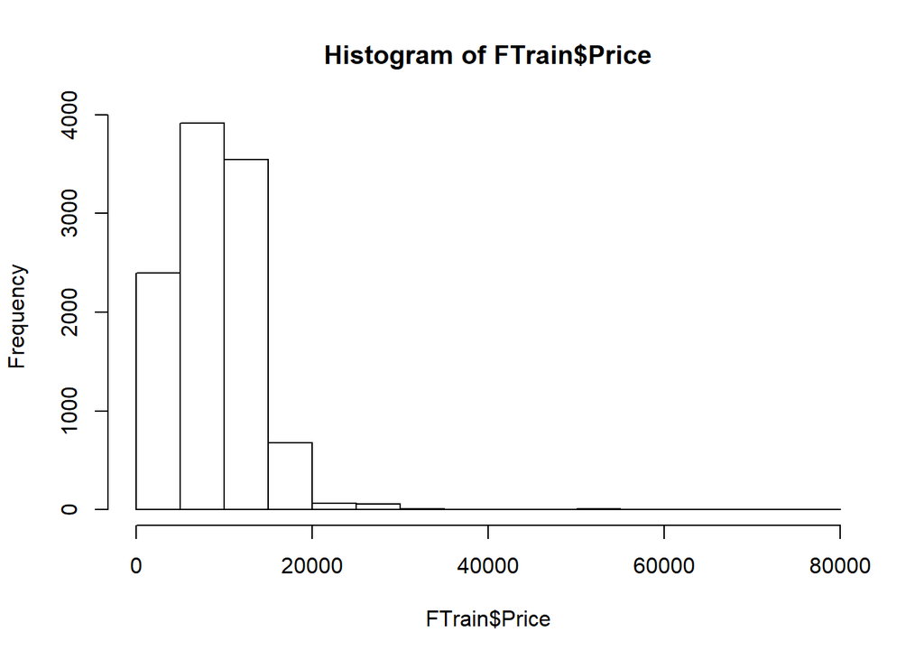

```r
# Outlier assesment in the dataset

hist(FTrain$Price)
```

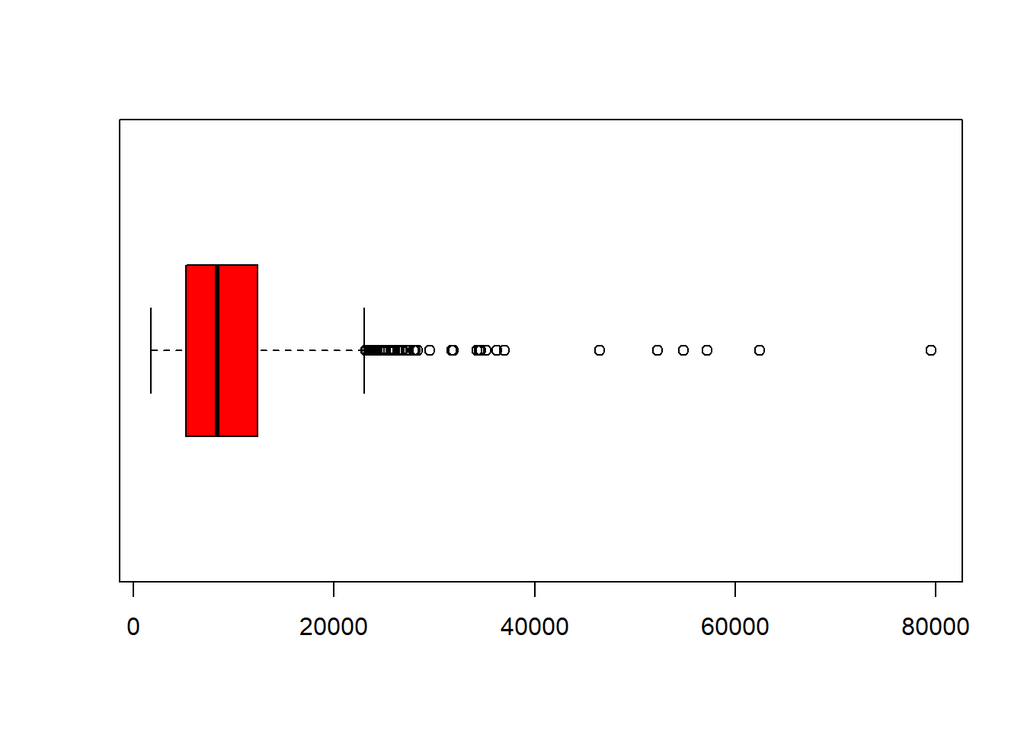

```r
boxplot(FTrain$Price, horizontal = TRUE, col="Red")
```

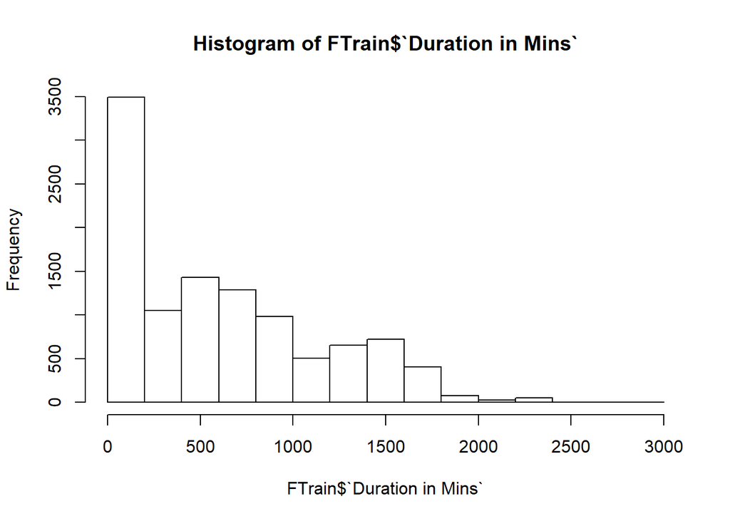

```r
hist(FTrain$`Duration in Mins`)
```

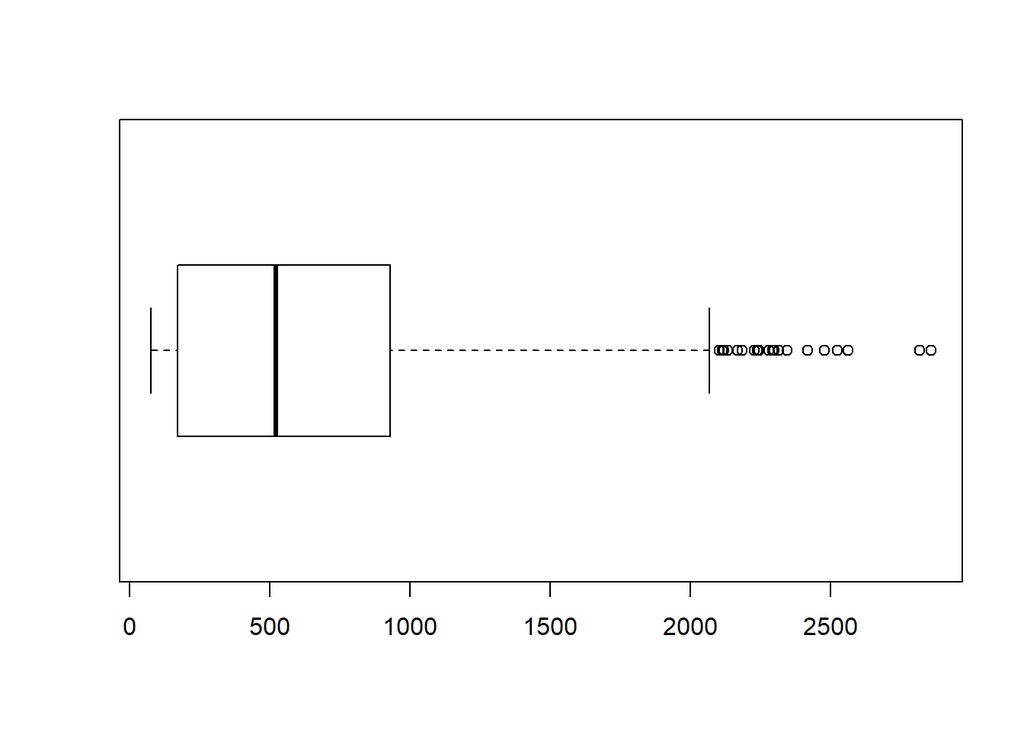

```r
boxplot(FTrain$`Duration in Mins`, horizontal = TRUE, Col="Green")
```

```r
summary(FTrain)
```

```
##               Airline     Date_of_Journey      Date of Travel
##  Jet Airways      :3849   Min.   :2019-03-01   09     :1406
##  IndiGo           :2053   1st Qu.:2019-03-27   06     :1288
##  Air India        :1752   Median :2019-05-15   27     :1130
##  Multiple carriers:1196   Mean   :2019-05-04   21     :1111
##  SpiceJet         : 818   3rd Qu.:2019-06-06   01     :1075
##  Vistara          : 479   Max.   :2019-06-27   24     :1052
##  (Other)          : 536                        (Other):3621
##  Month of Travel Year of Travel      Source        Destination
##  03:2724         2019:10683     Banglore:2197   Banglore :2871
##  04:1079                        Chennai : 381   Cochin   :4537
##  05:3466                        Delhi   :4537   Delhi    :1265
##  06:3414                        Kolkata :2871   Hyderabad: 697
##                                 Mumbai  : 697   Kolkata  : 381
##                                                 New Delhi: 932
##
##     Dep_Time                    Arrival-Time
##  Min.   :2020-03-01 00:20:00   Min.   :2020-03-01 00:05:00
##  1st Qu.:2020-03-01 08:00:00   1st Qu.:2020-03-01 08:45:00
##  Median :2020-03-01 11:50:00   Median :2020-03-01 14:05:00
##  Mean   :2020-03-01 12:53:51   Mean   :2020-03-01 13:45:37
##  3rd Qu.:2020-03-01 18:05:00   3rd Qu.:2020-03-01 19:15:00
##  Max.   :2020-03-01 23:55:00   Max.   :2020-03-01 23:55:00
##
##    Total_Stops       Price       Duration in Mins
##  1 stop  :5625   Min.   : 1759   Min.   :  75.0
##  2 stops :1520   1st Qu.: 5277   1st Qu.: 170.0
##  3 stops :  45   Median : 8372   Median : 520.0
##  4 stops :   1   Mean   : 9087   Mean   : 643.1
##  non-stop:3491   3rd Qu.:12373   3rd Qu.: 930.0
##  NA's    :   1   Max.   :79512   Max.   :2860.0
##
```

```r
colnames(FTrain)
```

```
##  [1] "Airline"          "Date_of_Journey"  "Date of Travel"
##  [4] "Month of Travel"  "Year of Travel"   "Source"
##  [7] "Destination"      "Dep_Time"         "Arrival-Time"
## [10] "Total_Stops"      "Price"            "Duration in Mins"
```

```r
str(FTrain)
```

```
## 'data.frame':    10683 obs. of  12 variables:
##  $ Airline         : Factor w/ 12 levels "Air Asia","Air India",..: 4 2 5 4 4 9 5 5 5 7 ...
##  $ Date_of_Journey : Date, format: "2019-03-24" "2019-05-01" ...
##  $ Date of Travel  : Factor w/ 10 levels "01","03","06",..: 9 1 4 5 1 9 5 1 5 10 ...
##  $ Month of Travel : Factor w/ 4 levels "03","04","05",..: 1 3 4 3 1 4 1 1 1 3 ...
##  $ Year of Travel  : Factor w/ 1 level "2019": 1 1 1 1 1 1 1 1 1 1 ...
##  $ Source          : Factor w/ 5 levels "Banglore","Chennai",..: 1 4 3 4 1 4 1 1 1 3 ...
##  $ Destination     : Factor w/ 6 levels "Banglore","Cochin",..: 6 1 2 1 6 1 6 6 6 2 ...
##  $ Dep_Time        : POSIXct, format: "2020-03-01 22:20:00" "2020-03-01 05:50:00" ...
##  $ Arrival-Time    : POSIXct, format: "2020-03-01 01:10:00" "2020-03-01 13:15:00" ...
##  $ Total_Stops     : Factor w/ 5 levels "1 stop","2 stops",..: 5 2 2 1 1 5 1 1 1 1 ...
##  $ Price           : num  3897 7662 13882 6218 13302 ...
##  $ Duration in Mins: num  170 445 1140 325 285 ...
```

[figure not shown]

```r
FTrain$CombineDate_Time =paste(FTrain$Date_of_Journey, FTrain$Dep_Time)

FTrain$CombineDate_Time=as.Date(FTrain$CombineDate_Time)
FTrain %>% ggplot( aes(FTrain$CombineDate_Time)) + geom_freqpoly(binwidth=86400)
```

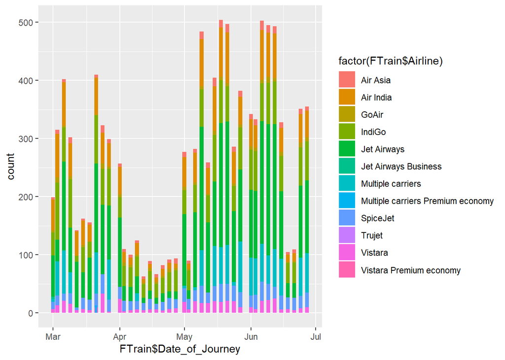

```r
ggplot(FTrain, aes(x = FTrain$Date_of_Journey, fill = factor(FTrain$Airline))) +
    geom_bar(stat = "count")
```

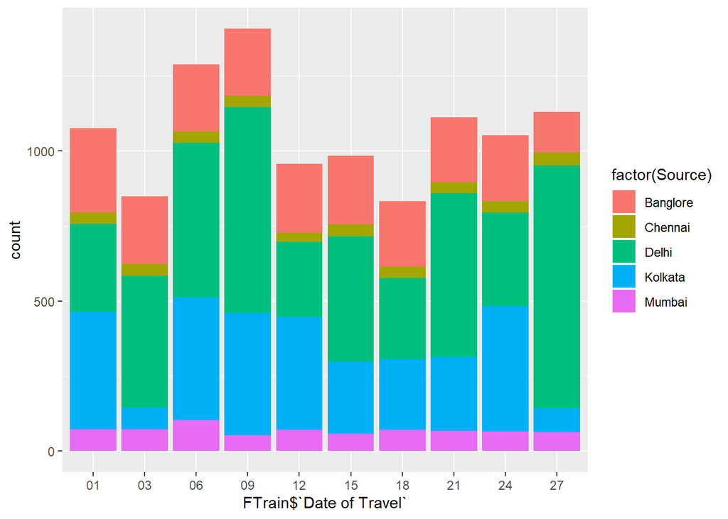

```r
ggplot(FTrain, aes(x = FTrain$`Date of Travel`, fill = factor(Source))) +
    geom_bar(stat = "count")
```

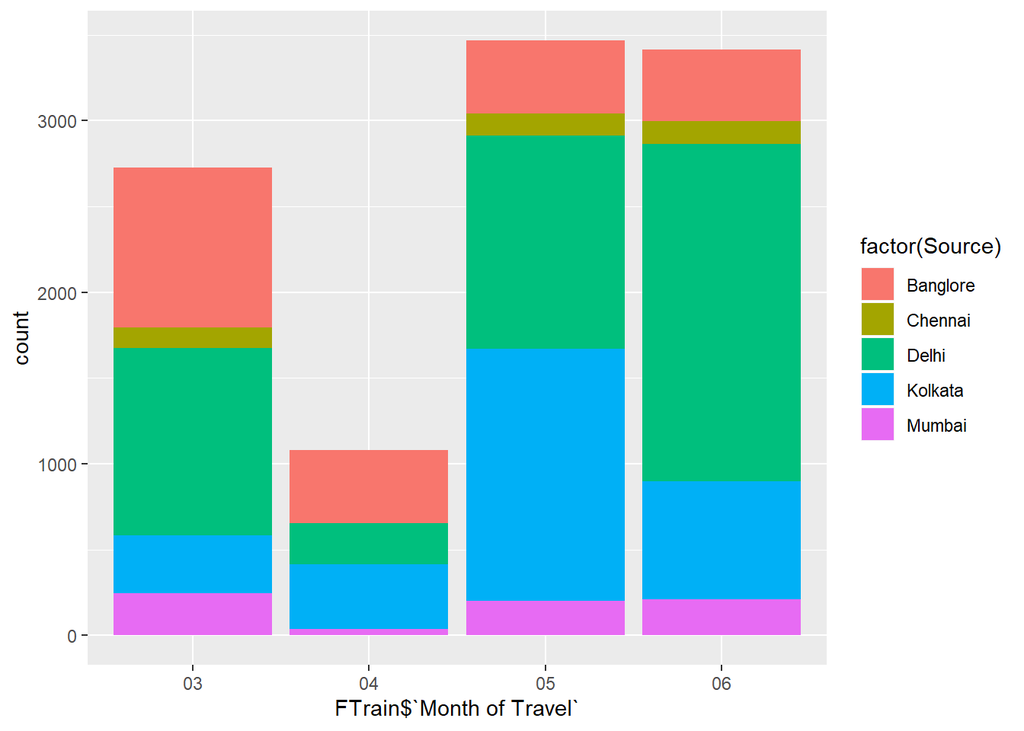

```r
ggplot(FTrain, aes(x = FTrain$`Month of Travel`, fill = factor(Source))) +
    geom_bar(stat = "count")
```

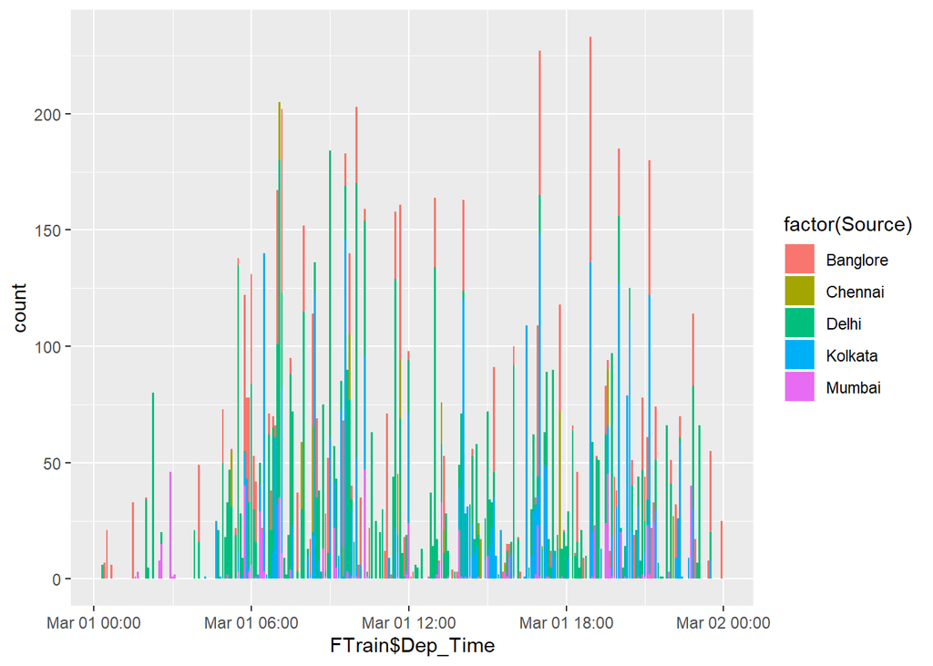

```r
ggplot(FTrain, aes(x = FTrain$Dep_Time, fill = factor(Source))) +
    geom_bar(stat = "count")
```

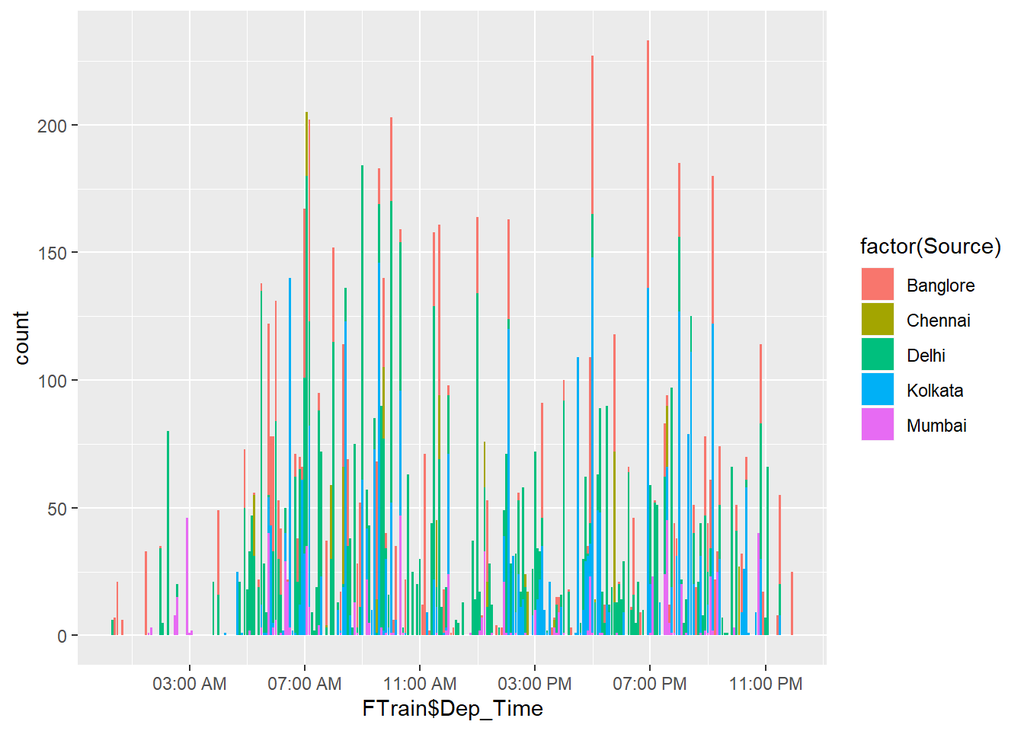

```r
ggplot(FTrain, aes(x = FTrain$Dep_Time, fill = factor(Source))) +
    geom_bar(stat = "count") +
      scale_x_datetime(date_breaks = "4 hour",
                       date_labels = "%I:%M %p")
```

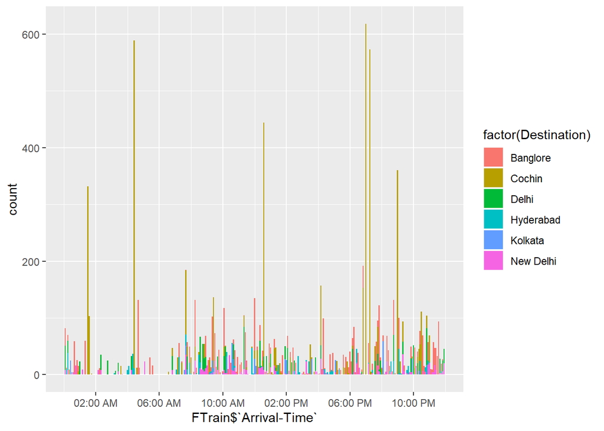

```r
ggplot(FTrain, aes(x = FTrain$`Arrival-Time`, fill = factor(Destination))) +
    geom_bar(stat = "count") +
      scale_x_datetime(date_breaks = "4 hour",
                       date_labels = "%I:%M %p")
```

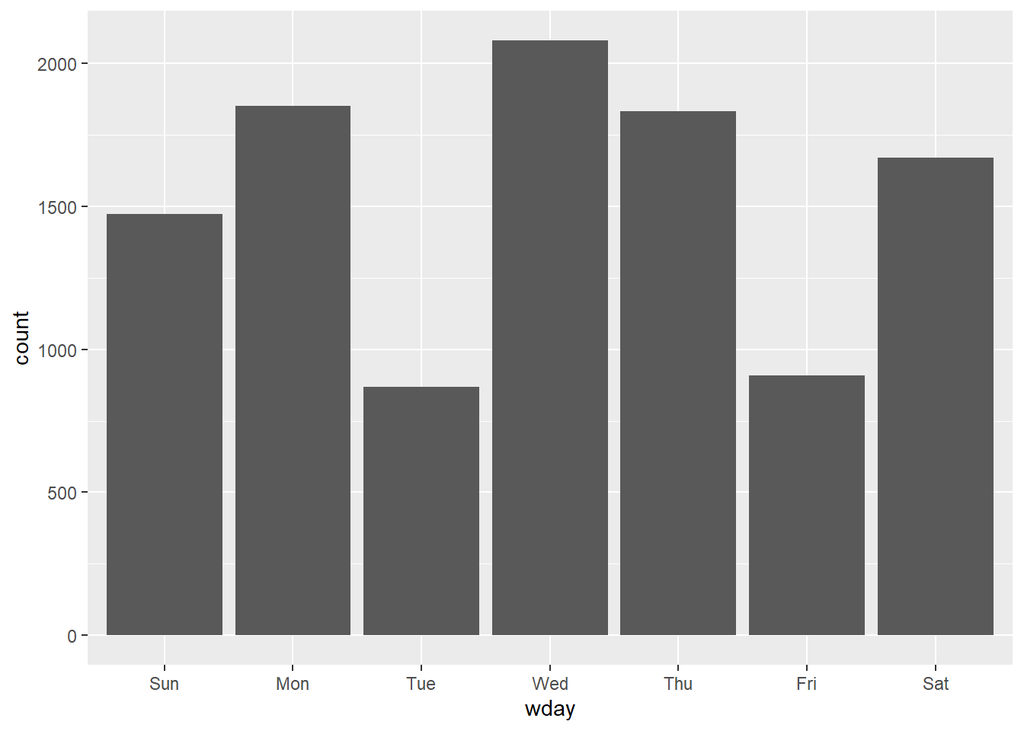

```r
#ggplot(FTrain, aes(x = FTrain$`Arrival-Time`, fill = factor(Destination))) +
#geom_bar(stat = "count") +
#scale_x_datetime(date_breaks = "2 hour",labels = date_format("%H:%M:%S"))


FTrain %>%
  mutate(wday = wday(FTrain$Date_of_Journey, label = TRUE)) %>%
  ggplot(aes(x = wday)) +
    geom_bar()
```

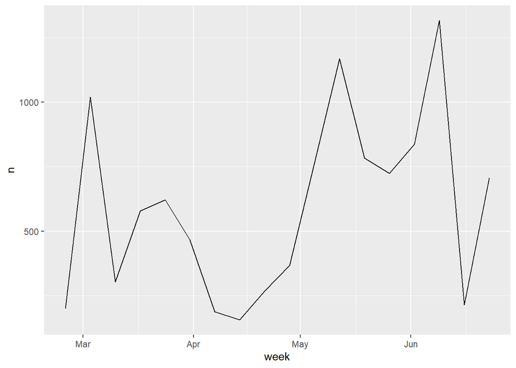

```r
FTrain %>%
  count(week = floor_date(FTrain$Date_of_Journey, "week")) %>%
  ggplot(aes(week, n)) +
    geom_line()
```

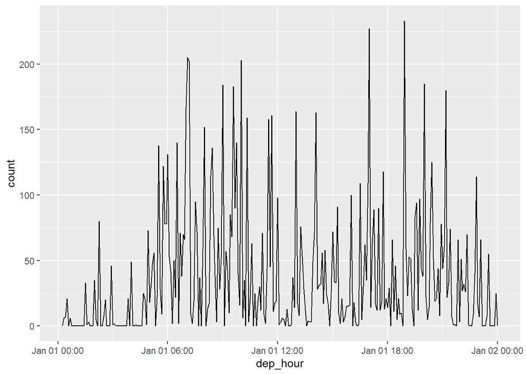

```r
FTrain %>%
  mutate(dep_hour = update(FTrain$Dep_Time, yday = 1)) %>%
  ggplot(aes(dep_hour)) +
    geom_freqpoly(binwidth = 300)
```

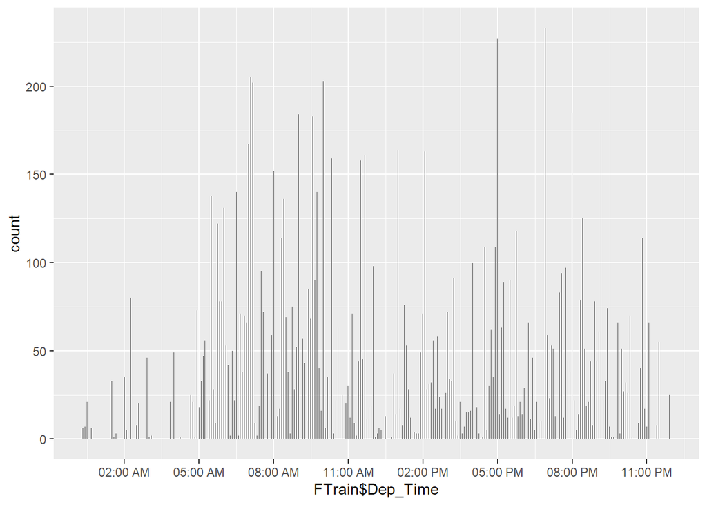

```r
ggplot(data = FTrain, aes(x = FTrain$Dep_Time)) +
  geom_histogram(binwidth = 50) + scale_x_datetime(date_breaks = "3 hour",
                       date_labels = "%I:%M %p")
```

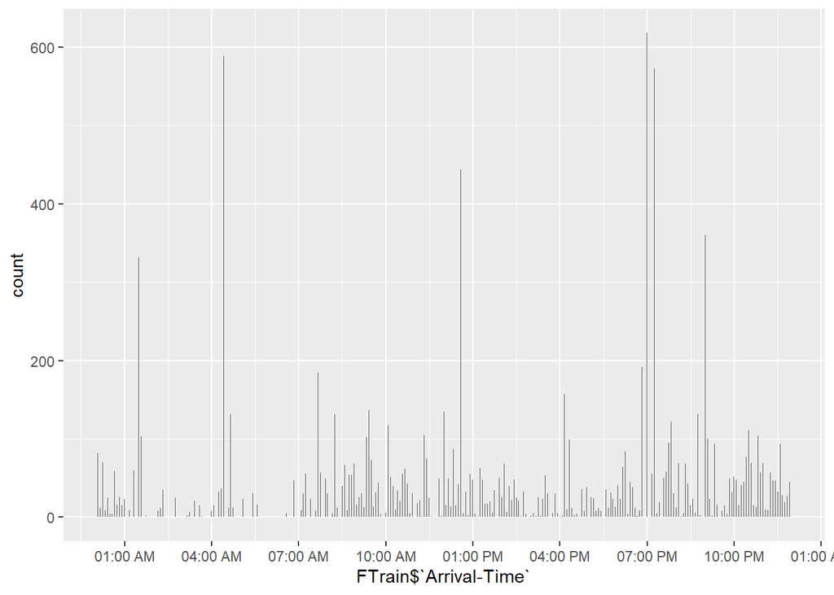

```r
ggplot(data = FTrain, aes(x = FTrain$`Arrival-Time`)) +
  geom_histogram(binwidth = 50) + scale_x_datetime(date_breaks = "3 hour",
                       date_labels = "%I:%M %p")
```